# Introduction to Probability

## About Probability

**Event:** In probability theory, an *event* is one or more of the possible outcomes of doing some thing. Example: If we toss a coin then getting a head would be an event and getting a head would be an event and getting a tail would be another event.

**Experiment:** The activity that produces such an event is referred to in probability theory as an experiment.

**Sample Space:** The set of all possible outcomes of an experiment is called the sample space for the experiment. In coin toss experiment, the sample space is:

S = {head, tail}

## Events

Events can be:

- **Independent**(each event is **not** affected by other events)
- **Dependent**(also called "conditional", where an event **is** affected by other events)
- **Mutually Exclusive**(events can't happen at the same time)
- **Collectively exhaustive list**(When a list of the possible events that can result from an experiment includes every possible outcome)

**Note:** Collectively exhaustive events: In probability theory and logic, a set of events is jointly or collectively exhaustive if at least one of the events must occur. For example: when rolling a six sided die, the outcomes 1,2,3,4,5,and 6 are collectively exhaustive, because they encompass the entire range of possible outcomes. Another way to describe collectively exhaustive events, is that their union must cover all the events within the entire sample space.

**Exercise:** Southern Bell is considering the distribution of funds for a campaign to increase long distance calls within North Carolina. The following table lists the markets that the company considers worthy of focused promotions:

| Market Segment | Cost of Special Campaign Aimed at Group |
| --- | --- |
| Minorities | 350,000 |
| Business People | 550,000 |
| Women | 250,000 |
| Professionals and white collar workers | 200,000 |
| Blue Collar workers | 250,000 |

There is up to $ 800,000 available for these special campaigns.

(a) Are the market segments listed in the table collectively exhaustive? Are they mutually exclusive?  
(b) Make a collectively exhaustive and mutually exclusive list of the possible events of the spending decision.  
(c) Suppose the company has decided to spend th eentire $ 800,000 0n special campaigns. Does this change your answer to part(b)? If so what is your new answer?

There are three types of Probability, like three types of conceptual approaches to solve probabilistic problem.

1. **Classical Approach**
2. **Relative frequency Approach**
3. **Subjective approach**

### Classical Probability:

This is same as the common probability theory we use.

$$ Probability\ of\ an\ event = \frac{number\ of\ outcomes\ where\ the\ event\ occurs}{total\ number\ of\ possible\ outcomes} $$

```python
#implementing the classical probability with python
def event_probability(event_outcomes, sample_space):
    """
    count the probability of an event.

    Paramrter Description:
    -----------------------

    event_outcomes: number of outcomes where the event occurs
    sample_space: total number of possible outcomes

    Returns:
    ----------
    probability of the event in percentage format

    Example:
    ----------
    >>> print(event_probability(13,52))
    >>> 25.0

    """
    probability = (event_outcomes/sample_space)*100
    return round(probability,1)
```

```python
# defining sample space
cards = 52

#event outcomes
hearts = 13

hearts_probability = event_probability(hearts,cards)
print(str(hearts_probability) + '%')
```

```
25.0%
```

Classical probability is often called a **priori probability** because if we keep using orderly examples such as fair coins, unbiased dice, and standard decks of cards, we can state the answer in advance (a priori) without tossing a coin, rolling a die, or drawing a card. We don't have to perform experiment to make probability of those events rather we can make statements based on logical reasoning.

#### Problems with classical approach:

This approach to probability is useful when we deal with card games, dice games, coin tosses, and the like, but has serious problems when we try to apply it to the less orderly decision problems we encounter in management. The classical approach to probability assumes a world that does not exist. It assumes away situations that are very unlikely but that could conceivably happen. Real life sutuations, disorderly and unlikely as they often are, make it useful to define probabilities in other ways.

### Relative frequency appraoch

Suppose if we want to know complex questions like "What is the probability that I will live to be 85?" or "What are the chances that I will blow on eof my stereo speakers if I turn my 200-watt amplifier up to wide open?". We quickly see that we may not be able to state in advance, without experimentation, what these probabilities are.

In 1800s, British Statisticians, interested in theoretical foundation for calculating risk of losses in life insurance, began defining probabilities from statistical data collected on births and deaths. Today this approach is called the *Relative Frequency of Occurance*. It defines probabilitiy of either:

1. The observed relative frequecny of an event in a very large number of trials,  
   or
2. The proportion of times that an event occurs in the long run when conditions are stable.

The method uses the relative frequencies of past occurrences as probabilities. we determine how often something has happened in the past and use that figure to predict the probability that it will happen again in the future.

For showing the example we can a see 100 coin toss example that how is it effecting the 0.5 probability of getting either head or tail from a coin toss.

```python
import pandas as pd
import numpy as np
import seaborn as sns
import matplotlib.pyplot as plt
```

```python
toss = pd.read_csv("data/CoinToss.csv")
```

```python
toss
```

|  | Toss | Coin1 | Coin2 | Coin1_h | Coin2_h |
| --- | --- | --- | --- | --- | --- |
| 0 | 1 | H | T | 1 | 0 |
| 1 | 2 | T | H | 0 | 1 |
| 2 | 3 | T | T | 0 | 0 |
| 3 | 4 | H | T | 1 | 0 |
| 4 | 5 | T | H | 0 | 1 |
| ... | ... | ... | ... | ... | ... |
| 95 | 96 | H | T | 1 | 0 |
| 96 | 97 | T | T | 0 | 0 |
| 97 | 98 | T | T | 0 | 0 |
| 98 | 99 | T | H | 0 | 1 |
| 99 | 100 | H | H | 1 | 1 |

100 rows × 5 columns

```python
toss = toss[['Toss','Coin1']]
```

```python
toss.rename(columns = {'Toss':'Count', 'Coin1':'Coin_result'}, inplace = True)
```

```python
toss
```

|  | Count | Coin_result |
| --- | --- | --- |
| 0 | 1 | H |
| 1 | 2 | T |
| 2 | 3 | T |
| 3 | 4 | H |
| 4 | 5 | T |
| ... | ... | ... |
| 95 | 96 | H |
| 96 | 97 | T |
| 97 | 98 | T |
| 98 | 99 | T |
| 99 | 100 | H |

100 rows × 2 columns

```python
toss_sum = toss.groupby(['Coin_result']).count()
```

```python
toss_sum
```

| Coin_result | Count |
| --- | --- |
| H | 42 |
| T | 58 |

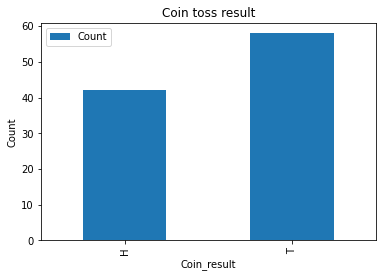

```python
toss_sum.plot(kind = "bar", title = "Coin toss result")
plt.ylabel('Count')
plt.show()
```

So here we can see if we toss a coin 100 times the result is not quite 0.5 in case. The amount of tail is prone to high. So that's an example of using relative frequency of occurance.

One difficulty with the relative frequency approach is that people often use it without evaluating a sufficient number of outcomes. If you heard someone say, "My aunt and uncle got the flu this year, and they are both over 65, so everyone in that age bracket will probably get the flu," So, it is clear that his observation were having insufficient data for establishing a relative frequency of occurance probability.

### Subjective Probabilities

Subjective probability refers to the probability of something happening based on an individual’s own experience or personal judgment. A subjective probability is not based on market data or historical information and differs from person to person. In other words, it is created from the opinion of an individual and is not based on fact.

In most types of probability, quantitative information is interpreted to determine the likelihood of something happening. However, subjective probability does not base its probability on quantitative information, is affected by personal beliefs, and contains no formal calculations.

Example:

An analyst is asked the probability of the S&P 500 will hit all-time highs in the coming months. The analyst looks at past trends and current market conditions and estimates that the probability of the S&P 500 will hit all-time highs at 20%.

### Important concept on classical probability problems

During solving any problem in classical approach, be sure to check whether the situation is "with replacement" after each draw or "without replacement". Let's see why is it important:

Let’s say you had a population of 7 people, and you wanted to sample 2. Their names are:

tanvir, tawhid, farabi, apon, mamun, sourav, anik  
You could put their names in a hat. If you sample with replacement, you would choose one person’s name, put that person’s name back in the hat, and then choose another name.  
When you sample with replacement, your two items are independent. In other words, one does not affect the outcome of the other. You have a 1 out of 7 (1/7) chance of choosing the first name and a 1/7 chance of choosing the second name.  
p(tanvir,tawhid) = (1/7) (1/7) = 0.02  
p(farabi,apon) = (1/7) (1/7) = 0.02  
and so on,

but when we are doing **without replacement:**  
But now, your two items are dependent, or linked to each other. When you choose the first item, you have a 1/7 probability of picking a name. But then, assuming you don’t replace the name, you only have six names to pick from. That gives you a 1/6 chance of choosing a second name. The odds become:  
p(tanvir,tawhid)= (1/7) (1/6) = 0.024  
p(farabi,apon) = (1/7) (1/6) = 0.024

Let's test our concept: Classify the following probability estimates as to their type (classical, relative frequecy or subjective):  
(a) The probability of scoring on a penalty shot in ice hockey is 0.47  
(b) The probability that the current mayor will resign is 0.85  
(c) The probability of rolling two sixes with two dice is 1/36  
(d) The probability that a president elected in a year ending in zero will die in office is 7/10  
(e) The probability that you will go to Europe this year is 0.14

## Probability Rules

Most managers who use probabilities are concerned with two conditions:

1. The case where one event or another will occur.
2. The situation where two or more events will both occur.

**Addition Rule for mutually exclusive events:** If two events are mutually exclusive, we can express this probability using the addition rule for mutually exclusive events.

$$ P(A\ or\ B) = P(A) + P(B) $$

**Addition Rule for events that are not mutually exclusive:** if two events are not mutually exclusive, it is possible for both events to occur. In this case we will have to omit the probability of happening both event.

$$ P(A\ or\ B) = P(A) + P(B) - P(AB) $$

There is a nice diagrammatic way to illustrates these probabilities rules. We use a pictorial representation called a *Venn Diagram*, after the nineteenth century English mathematician John Venn. In these diagram, the entire sample space is represented nu a rectange, and events are represented by parts of the rectangle. If two events are mutually exclusive their parts of the rectangle will not overlap each other otherwise if two events are not mutually exclusive then they will overlap.

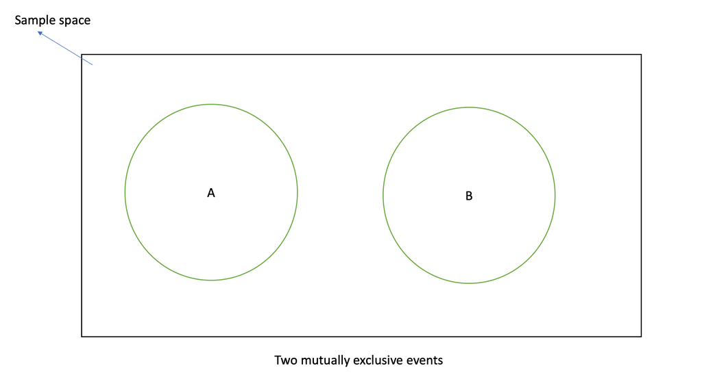

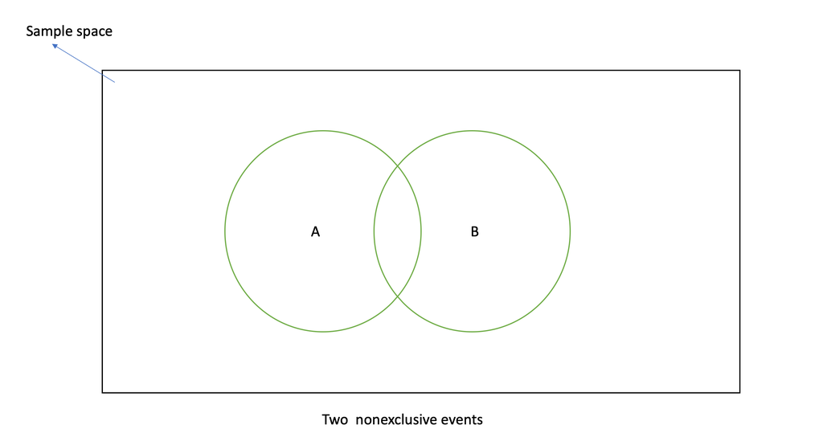